# 260-2017-04-24-speed-lab

2017-04-24 09:46:06

## Today's topic

- Measuring the speed of nervous system conduction
- And, a tiny lesson in open, transparent, reproducible data science

[figure not shown]

## Question

- How fast does the nervous system conduct information?
- [Prior evidence](https://psu-psychology.github.io/psych-260-spring-2017/lecture-notes/260-2017-03-29-somatosensation.html#15)
  - Proprioception vs. touch
- Why do we care?

## Prediction

We predict that the speed of conduction will be …

## Scheme

- Speed = Distance/Time
- Chain of participants to make distance larger
  - If typical person ~ 1.5 m, then
  - at s=30 m/s, t = d/s -> 1.5/30 = 0.05 secs.

## Condition 1 (ankle)

- Squeeze ankle
- ankle_shoulder + shoulder_brain + brain_decide + brain_shoulder + shoulder_hand

## Condition 2 (shoulder)

- Squeeze shoulder
- shoulder_brain + brain_decide + brain_shoulder + shoulder_hand
- Condition 1 - Condition 2
- ankle_shoulder + shoulder_brain + brain_decide + brain_shoulder + shoulder_hand

## Measure

- sum(ankle_shoulder) for all participants -> Distance
- mean(time(Condition 1)) - mean(time(Condition 2)) -> Time
- Speed = Distance/Time

## Materials

- Stop watch
- Tape measure

## Decisions

- Same hand or dominant?
- Alternate ankle/shoulder or one condition before the other?
- How many trials?
  - Fixed number?
  - When reach asymptote?

## Data files

- Data file with [body measurements](https://docs.google.com/spreadsheets/d/1NFGu-M4AGf_4IHf-o4y3sCHUZ3Ao-CpBUpXqCsQrAIg/edit#gid=0)
  - participant, ankleshoulder (cm)
- Data file with [reaction times](https://docs.google.com/spreadsheets/d/1NFGu-M4AGf_4IHf-o4y3sCHUZ3Ao-CpBUpXqCsQrAIg/edit#gid=1626241513)
  - trial {1…n}, condition {ankle, shoulder}, time (s)

```r
# Load R packages
library("googlesheets")
suppressPackageStartupMessages(library("dplyr"))
suppressPackageStartupMessages(library("ggplot2"))
```

## Measuring distance

```r
psych260 <- gs_title("psych-260-spring-2017")
```

```
## Sheet successfully identified: "psych-260-spring-2017"
```

```r
psych260 %>%
  gs_read(ws = "distance") ->
  distance
```

```
## Accessing worksheet titled 'distance'.
```

```
## No encoding supplied: defaulting to UTF-8.
```

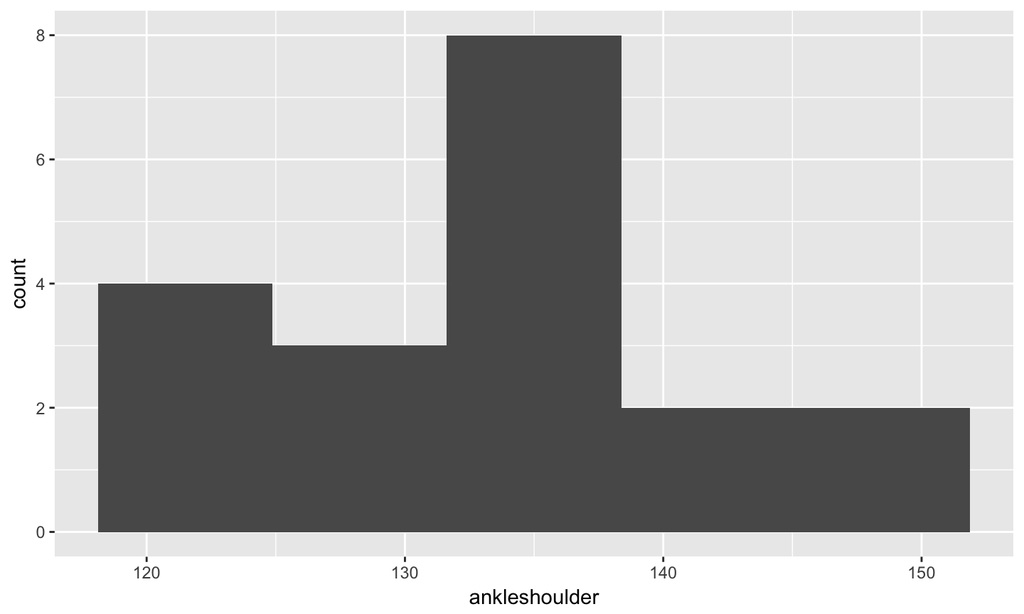

```r
dist.hist <- ggplot(data = distance, aes(x=ankleshoulder)) +
  geom_histogram(bins = 5)
```

## Sum distance

```r
with(distance, summary(ankleshoulder))
```

```
##    Min. 1st Qu.  Median    Mean 3rd Qu.    Max.
##   122.0   125.5   132.0   133.2   137.5   149.0
```

```r
# Calculate sum
dist.sum = with(distance, sum(ankleshoulder))
```

The total distance is 2531 cm.

## Measuring time

```r
psych260 %>%
  gs_read(ws = "time") ->
  time
```

```
## Accessing worksheet titled 'time'.
```

```
## No encoding supplied: defaulting to UTF-8.
```

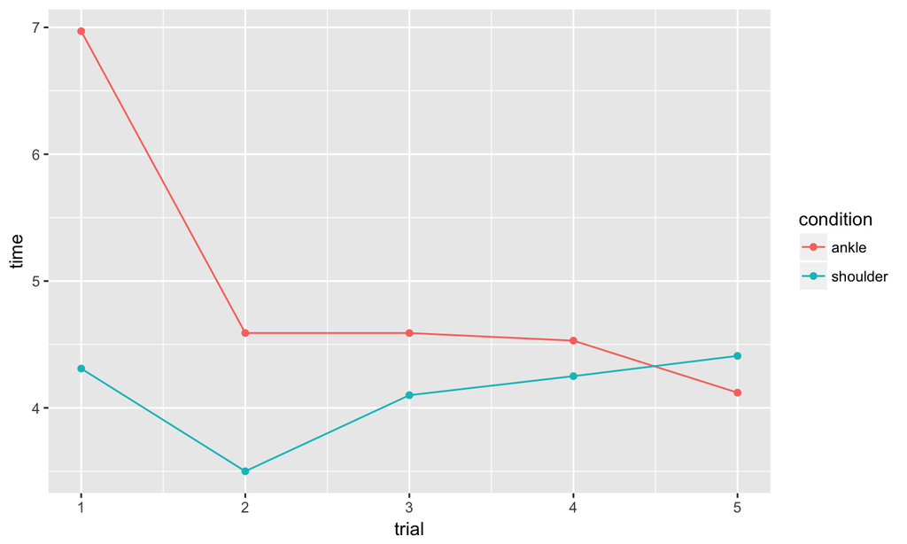

```r
# Plot data
time.plot = ggplot(data = time, aes(x=trial, y=time, color=condition)) +
  geom_point() +
  geom_line()
```

## Calculate time difference

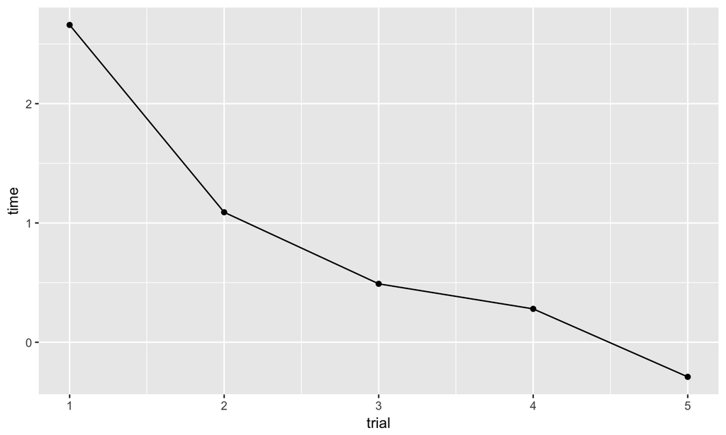

```r
time %>%
  filter(condition == "ankle") ->
  ankle.times

time %>%
  filter(condition == "shoulder") ->
  shoulder.times

time.diff <- data_frame(trial=unique(time$trial),
                        time=ankle.times$time - shoulder.times$time)

time.diff.plot = ggplot(data = time.diff, aes(x=trial, y=time)) +
  geom_point() +
  geom_line()
```

## Calculating speed

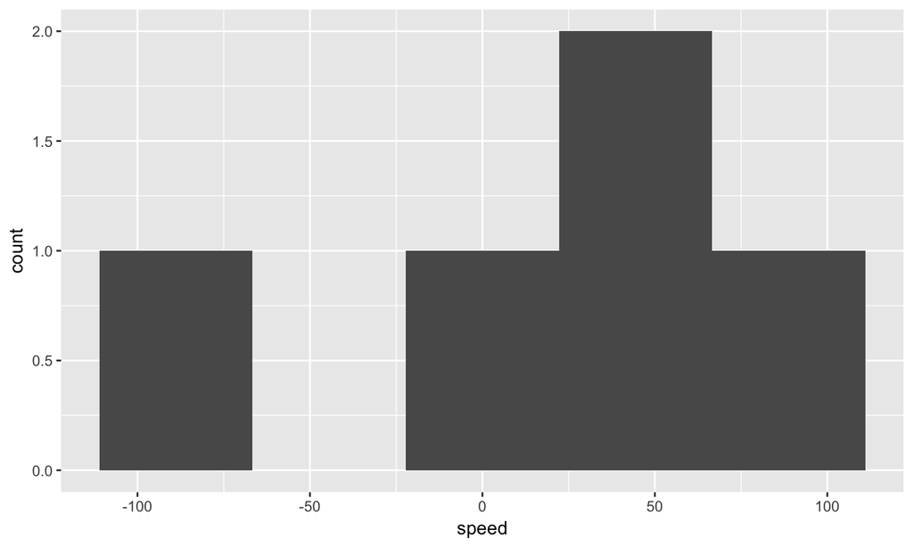

```r
time.diff$speed <- (dist.sum)*.01/time.diff$time

speed.hist <- ggplot(data = time.diff, aes(x=speed)) +
  geom_histogram(bins = 5)
```

## Plot time series of speeds

```r
speed.plot <- ggplot(data = time.diff, aes(x=trial, y=speed)) +
  geom_point() +
  geom_line()
```

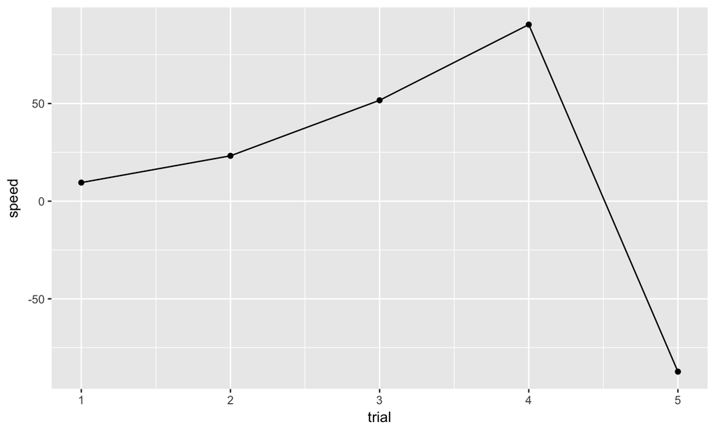

```r
speed.plot
```

## Summarizing findings

- We tested the mean speed of neural propagation in a sample of n=19 college-age adults.
- The mean speed of neural propagation over 5 trials was 17.5 m/s with a range of [-87.28, 90.39] m/s.
- These findings are/are not generally in accord with values we would expect from the literature.

## Limitations

## How to replicate/extend

## Contributors

## Resources

This document was prepared in RStudio 1.0.36 on 2017-04-24 09:46:13.